# Отчёт по лабораторной работе №16

Базовая защита от атак типа «brute force»

Жукова Арина Александровна

1132239120@rudn.ru

Российский университет дружбы народов

2025-12-20

# Информация

## Докладчик

- Жукова Арина Александровна
- Направление прикладная информатика
- Студентка 3 курса
- Группа НПИбд-01-23
- Российский университет дружбы народов им. П. Лумумбы
- 1132239120@rudn.ru

# Вводная часть

## Актуальность

- Атаки типа «brute force» (перебор паролей) остаются одной из самых распространённых угроз для серверов, доступных из сети Интернет.
- Неудачные попытки подбора пароля создают высокую нагрузку на службы (SSH, HTTP) и маскируют другие виды атак.
- Автоматизированная блокировка источников атак критически важна для поддержания безопасности и доступности сервисов.

## Цели и задачи

**Цель работы:** Получить практические навыки работы с программным средством Fail2ban для обеспечения базовой защиты от атак типа «brute force».

**Задачи:**

1. Установить и настроить Fail2ban для отслеживания работы установленных на сервере служб.
2. Проверить работу Fail2ban посредством попыток несанкционированного доступа с клиента на сервер через SSH.
3. Написать скрипт для Vagrant, фиксирующий действия по установке и настройке Fail2ban.

## Материалы и методы

- **Операционная система:** Rocky Linux 10
- **Программное обеспечение:**
  - `fail2ban` — система обнаружения и блокировки атак.
  - `firewalld` / `iptables` — межсетевой экран для применения блокировок.
  - `ssh`, `apache`, `postfix`, `dovecot` — защищаемые службы.
- **Методология:** Поэтапная настройка защиты, практическое тестирование блокировок, автоматизация процесса с помощью скриптов.

# Настройка защиты с помощью Fail2ban

## Установка и базовый запуск

Установка пакета

`dnf -y install fail2ban`

Запуск и добавление в автозагрузку

`systemctl start fail2ban systemctl enable fail2ban`

Мониторинг логов в реальном времени

```
tail -f /var/log/fail2ban.log
```

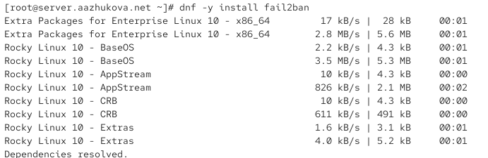

Установка и запуск fail2ban

## Настройка защиты службы SSH

В файл `/etc/fail2ban/jail.d/customisation.local` добавлены настройки для SSH:

- Время блокировки (`bantime`) установлено на 1 час (3600 секунд).
- Защита для стандартного порта SSH и порта 2022.
- Активированы фильтры для защиты от DDoS и с учетом политик SELinux.

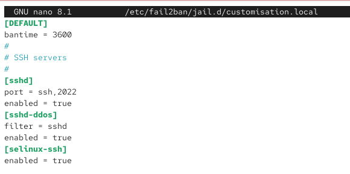

Конфигурация защиты SSH

## Настройка защиты веб-сервера (HTTP/HTTPS)

В тот же файл добавлены правила для защиты сервисов Apache от различных типов атак, таких как атаки на аутентификацию, боты, попытки выполнения скриптов и переполнения буфера.

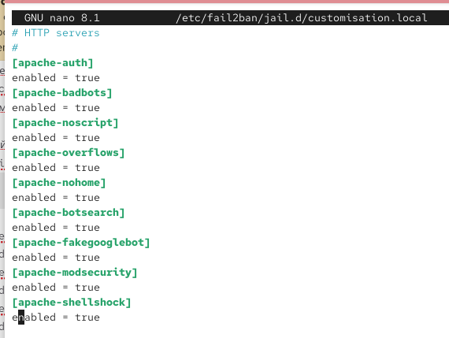

Конфигурация защиты Apache

## Настройка защиты почтовых сервисов

Добавлена конфигурация для мониторинга и блокировки атак на почтовые серверы Postfix и Dovecot.

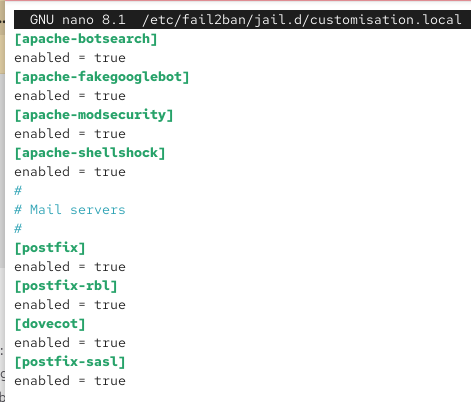

Конфигурация защиты почты

# Проверка работы Fail2ban

## Проверка статуса и настройка параметров

Общий статус fail2ban

`fail2ban-client status`

Статус конкретной “тюрьмы” для sshd

`fail2ban-client status sshd`

Изменение параметра для sshd

`fail2ban-client set sshd maxretry 2`

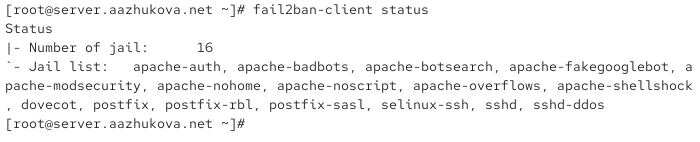

Проверка статуса fail2ban

## Тестирование блокировки при неудачных попытках входа

1. С клиентской машины выполняются попытки подключения по SSH с неверным паролем.
2. После превышения лимита попыток (`maxretry`) IP-адрес клиента блокируется.
3. Командой `fail2ban-client status sshd` можно убедиться в наличии блокировки.

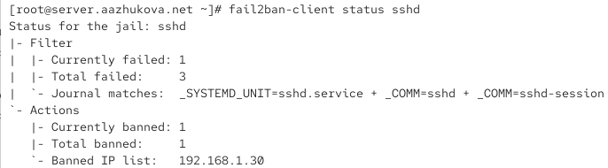

IP-адрес клиента заблокирован

## Разблокировка IP-адреса и добавление в исключения

Ручная разблокировка IP `fail2ban-client set sshd unbanip <client_ip>`

Для постоянного исключения IP-адреса (например, доверенной сети) его нужно добавить в параметр `ignoreip` в конфигурационном файле.

```
[DEFAULT]
bantime = 3600
ignoreip = 127.0.0.1/8 <client_ip>
```

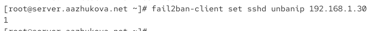

IP-адрес клиента разблокирован

# Автоматизация развёртывания

## Создание скрипта автоматической настройки

Создан скрипт `protect.sh`, который устанавливает fail2ban и копирует подготовленные конфигурационные файлы. Это позволяет быстро разворачивать защиту на новых серверах.

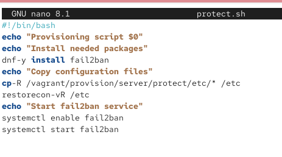

Содержание скрипта protect.sh

## Интеграция скрипта с Vagrant для автоматического provision

Конфигурационный скрипт добавлен в `Vagrantfile`. Это гарантирует, что при создании виртуальной машины защита Fail2ban будет настроена автоматически.

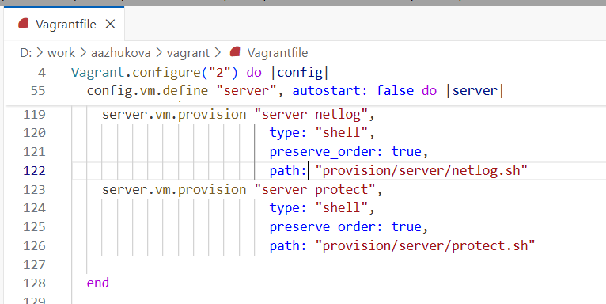

Фрагмент Vagrantfile

# Результаты

## Подтверждение работоспособности

- **Fail2ban успешно установлен и работает как служба.**
- **Настроена защита ключевых сервисов:** SSH, Apache, Postfix, Dovecot.
- **Механизм блокировки работает корректно:** IP-адрес атакующего блокируется после заданного количества неудачных попыток.
- **Функционал управления подтверждён:** Ручная разблокировка IP и добавление адресов в белый список (`ignoreip`) работают штатно.
- **Достигнута автоматизация:** Созданный скрипт и его интеграция с Vagrant позволяют воспроизводить конфигурацию на любом новом стенде.

# Выводы

## Итоги проделанной работы

- **Получены практические навыки** по установке, настройке и администрированию системы Fail2ban.
- **Настроен и проверен комплекс правил** для защиты основных сетевых служб (SSH, HTTP, почта) от атак подбора учётных данных.
- **Освоены ключевые операции:** мониторинг логов, проверка статуса блокировок, ручное управление (бан/разбан IP).
- **Реализован процесс автоматизации** с помощью скрипта на Bash и его интеграции в Vagrant, что соответствует современным практикам DevOps.
- **Создана готовая к использованию конфигурация**, которую можно применять для базовой защиты реальных серверов.

## Значение для обеспечения безопасности

- Fail2ban является **эффективным и легковесным** инструментом для отражения массовых автоматизированных атак.
- **Снижение нагрузки** на системные логи и сами службы за счёт ранней блокировки источников атак.
- **Централизованное управление** безопасностью на уровне межсетевого экрана на основе анализа поведения.
- **Гибкость настройки** позволяет адаптировать уровень защиты под конкретные требования и политики безопасности.